# Bonus_Exercise_Late_Submission

Emre Kemal Yurderi

08 11 2020

## Istanbul’s Property Market

```r
tail(data_rename)
```

```
## # A tibble: 6 x 9
##   Tarih Toplam_Satis Ipotekli_Satis Ilk_el_Satis Ikinci_el_Satis Yabanci_Satis
##   <chr>        <dbl>          <dbl>        <dbl>           <dbl>         <dbl>
## 1 2020~         6113           2451         2022            4091           374
## 2 2020~         7640           2570         2546            5094           423
## 3 2020~        28799          14767         8253           20546           730
## 4 2020~        39432          24000        10429           29003          1046
## 5 2020~        30292          15367         8103           22189          1648
## 6 2020~        25399           7527         7099           18300          2370
## # ... with 3 more variables: Ist_Fiyat_indeks <dbl>, TR_Fiyat_indeks <dbl>,
## #   Ist_Br_Fiyat <dbl>
```

## Bar Chart - Seasonal Sales

If there is a seasonality in the sales or not? To investigate that, the date column splitted to Year and Month (named data_rename) and grouped by year to count the months for each year.

```r
data_rename %>%
  count(Yıl, sort=TRUE)
```

```
## # A tibble: 11 x 2
##    Yıl       n
##    <chr> <int>
##  1 2010     12
##  2 2011     12
##  3 2012     12
##  4 2013     12
##  5 2014     12
##  6 2015     12
##  7 2016     12
##  8 2017     12
##  9 2018     12
## 10 2019     12
## 11 2020      9
```

Since there is only 9 months for 2020, and the data before 2010 is not available, seasonality comparison have done only for the years from 2010 to 2019.

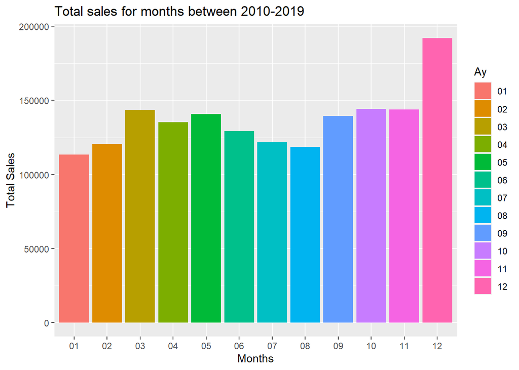

```r
ggplot(top_ay_data, aes(x=Ay, y=top_satis, fill=Ay)) +
  geom_col()+
  labs(title="Total sales for months between 2010-2019",
       x= "Months",
       y="Total Sales")
```

According to the bar graph, the last month of the year is the busiest time for the market.

## Line Chart - Sales Types

We can compare the sales types (first hand, second hand etc.) by the years in a line graph. The average of sales types for each year is calculated and then melted to draw a line plot that include all types of sales.

```r
ort_yil_data_long <-
  ort_yil_data %>%
  gather(key, values, c("ort_satis", "ort_ipotek", "ort_Ilk_el","ort_Ikinci_el", "ort_yabanci"))
head(ort_yil_data_long,3)
```

```
## # A tibble: 3 x 3
##   Yıl   key       values
##   <chr> <chr>      <dbl>
## 1 2013  ort_satis 19566.
## 2 2014  ort_satis 18788.
## 3 2015  ort_satis 19981.
```

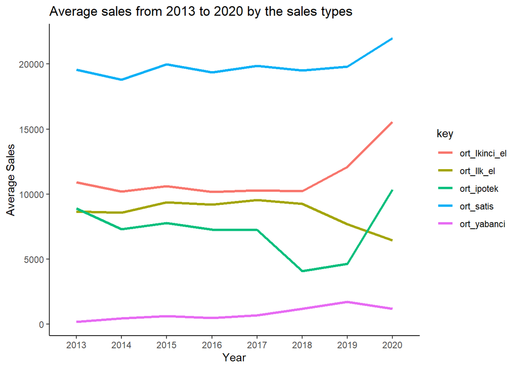

```r
ggplot(ort_yil_data_long, aes(x=Yıl, y=values, color=key, group = key)) +
  geom_line(size=1.2) +
  theme_classic() +
  labs(title  = "Average sales from 2013 to 2020 by the sales types",
       x = "Year", y = "Average Sales" )
```

The chart depicts, the gap between first hand and second hand property sales started to expand since 2018. Second hand housing sales surged almost 50% in 2 years. On the other hand, first hand property sales started to a downward trend in the same year. In addition, mortgage sales have the highest increase, with doubling itself in a single year which is in 2020.

## Scatter Plot - Price Index

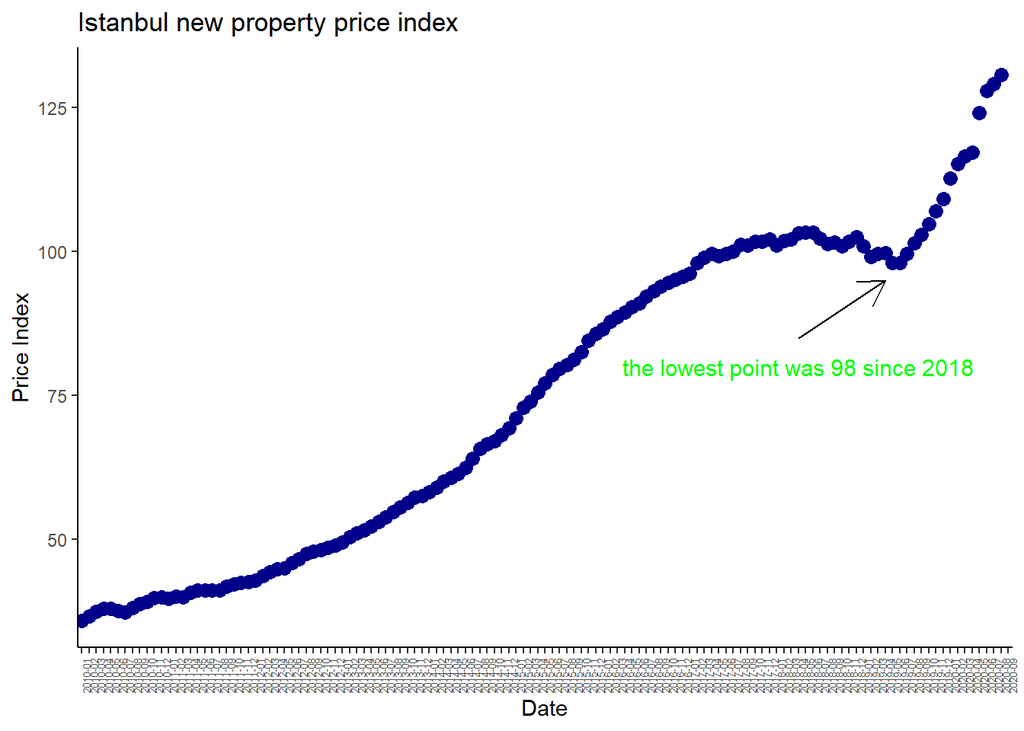

```r
annotation <- data.frame(
  x = 100,
  y = 80,
  label = "the lowest point was 98 since 2018")


ggplot(data_scatter, aes(y=Ist_Fiyat_indeks, x=Tarih)) +
  geom_point(size=3, color="darkblue") +
  geom_segment(aes(x = 100, y = 85, xend = 112, yend = 95)) +
  geom_segment(aes(x = 100, y = 85, xend = 112, yend = 95),
               arrow = arrow(length = unit(0.5, "cm"))) +
  geom_text(data=annotation, aes( x=x, y=y, label=label),                 ,
            color="green",
            size=4 , angle=0) +
  labs(title="Istanbul new property price index",
       x = "Date",
       y = "Price Index") +
  theme_classic() +
  theme(axis.text.x = element_text(angle=90, size=5))
```

According to the scatter plot of Istanbul’s property price index, there is a strong upward trend through the years and it reached its’ all time high in 2020.